# Analiza zmogljivosti procesorjev in grafičnih kartic

Andrej Erjavec

2023-06-06

## Uvod

Zaradi stalnega razvoja in vlaganja v razvoj računalniških čipov se zmogljivost le-teh iz leta v leto povečuje. K temu največ pripomorejo izboljšave na področju litografije, ki je proces tiskanja tranzistorjev na silicijevo ploščo. Posledično se velikosti tranzistorjev iz leta v leto manjšajo, kar omogoča integracijo vse večjega števila tranzistorjev na površino čipa, kar pomeni povečanje zmogljivosti. Manjši tranzistorji nimajo ugodnega vpliva le na zmogljivost, ampak tudi na učinkovitost čipov. Zaradi vse manjših razdalj med njimi se nemreč zmanjša tudi poraba energije.

Trend, ki napoveduje razvoj čipov v smislu števila tranzistorjev, se opira na Moorov zakon iz leta 1965 (Britannica 2023), ki pravi, da se število tranzistorjev na tiskanem vezju podvoji približno vsaki dve leti. Moorov zakon sicer ni pravilo, ampak temelji na večletnem opazovanju večanja števila tranzistorjev in zmogljivosti čipov.

V okviru te analize bi rad na realnih podatkih čipov predstavil trend povečevanja zmogljivosti in opazoval korelacijo med zmogljivostjo, porabo energije in številom tranzistorjev pri računalniških procesorjih in grafičnih karticah. Obenem bi preveril ali Moorov zakon v zadnjih nekaj letih še vedno velja.

## Predstavitev podatkov

Podatki iz zbirke **CPU and GPU Performances Dataset** (BRYANT 2022) pokrivajo vse glavne računalniške procesorje in grafične kartice v obodbju med letoma 2000 in 2021.

| X | Product | Type | Release.Date | Process.Size..nm. | TDP..W. | Die.Size..mm.2. | Transistors..million. | Freq..MHz. | Foundry | Vendor | FP16.GFLOPS | FP32.GFLOPS | FP64.GFLOPS |
| --- | --- | --- | --- | --- | --- | --- | --- | --- | --- | --- | --- | --- | --- |
| 0 | AMD Athlon 64 3500+ | CPU | 2007-02-20 | 65 | 45 | 77 | 122 | 2200 | Unknown | AMD | NA | NA | NA |
| 1 | AMD Athlon 200GE | CPU | 2018-09-06 | 14 | 35 | 192 | 4800 | 3200 | Unknown | AMD | NA | NA | NA |
| 2 | Intel Core i5-1145G7 | CPU | 2020-09-02 | 10 | 28 | NA | NA | 2600 | Intel | Intel | NA | NA | NA |
| 3 | Intel Xeon E5-2603 v2 | CPU | 2013-09-01 | 22 | 80 | 160 | 1400 | 1800 | Intel | Intel | NA | NA | NA |
| 4 | AMD Phenom II X4 980 BE | CPU | 2011-05-03 | 45 | 125 | 258 | 758 | 3700 | Unknown | AMD | NA | NA | NA |
| 5 | Intel Xeon E5-2470 v2 | CPU | 2013-09-01 | 22 | 95 | 160 | 1400 | 2400 | Intel | Intel | NA | NA | NA |

- **Product:** Naziv procesorja oziroma grafične kartice (tip: character)
- **Type:** Tip izdelka (CPU - procesor | GPU - grafična kartica) (tip: character)
- **Release.Date:** Datum izdaje izdelka (tip: date)
- **Process.Size..nm.:** Velikost tranzistorja oz. proizvodni proces v nm (tip: numeric)
- **TDP..W.:** Thermal Design Power - poraba energije pri maksimalni obremenitvi v W (tip: numeric)
- **Die.Size..mm.2:** Velikost integriranega vezja v mm^2 (tip: numeric)
- **Transistors..million.:** Število tranzistorjev v milijonih (tip: numeric)
- **Freq..MHz.:** Frekvenca procesorja v MHz (tip: numeric)
- **Foundry:** Proizvajalec čipa (tip: character)
- **Vendor:** Proizvajalec procesorja /grafične kartice (tip: character)

Naslednji stoplci so relavantni samo za grafične kartice:

- **FP16.GFLOPS:** Zmogljivost pri 16-bitnih operacijah s plavajočo vejico (tip: numeric)
- **FP32.GFLOPS:** Zmogljivost pri 32-bitnih operacijah s plavajočo vejico (tip: numeric)
- **FP64.GFLOPS:** Zmogljivost pri 64-bitnih operacijah s plavajočo vejico (tip: numeric)

## Anliza podatkov

Z uporabo tabel in grafov bi rad bolje predstavil podatke, korelacije med njimi in lastnosti ter ugotovitve, ki jih lahko iz njih izpeljem.

Pred začetkom glavnega dela analize bom predstavil sestavo podatkov po proizvajalcu in tipu produkta ter preveril kateri proizvajalci proizvedejo največ čipov.

### Sestava podatkov po proizvajalcu in tipu produkta

Sestava podatkov po proizvajalcu in tipu produkta

| Vendor | Type | n |
| --- | --- | --- |
| Intel | CPU | 1242 |
| AMD | CPU | 950 |
| NVIDIA | GPU | 1201 |
| AMD | GPU | 712 |
| ATI | GPU | 535 |
| Intel | GPU | 150 |
| Other | GPU | 64 |

Pred izdelavo tabele deležev proizvajalcev sem iz podatkov odstranil vse izdelke, pri katerih proizvajalec čipa ni znan oziroma ima v tabeli atribut *Foundry* označen kot *Unknown*.

### Delež proizvedenih čipov po proizvjalcih

Delež proizvedenih čipov po proizvjalcih

| Foundry | n | percentage |
| --- | --- | --- |
| TSMC | 2178 | 54.61 |
| Intel | 1390 | 34.85 |
| GF | 265 | 6.64 |
| UMC | 79 | 1.98 |
| Samsung | 60 | 1.50 |
| Sony | 10 | 0.25 |
| IBM | 3 | 0.08 |
| NEC | 2 | 0.05 |
| Renesas | 1 | 0.03 |

Največji proizvajalec čipov je podjetje TSMC, ki proizvede dobro polovico vseh čipov. Sledi podjetje Intel s približno 35 odstotnim deležem. Ostala podjetja proizvedejo skupaj dobrih 10% čipov.

### Glavni proizvajalci čipov za procesorje

Proizvajalci čipov za procesorje

| Foundry | n | percentage |
| --- | --- | --- |
| Intel | 1242 | 56.66 |
| Unknown | 760 | 34.67 |
| TSMC | 97 | 4.43 |
| GF | 93 | 4.24 |

Če si ogledamo samo izdelke tipa CPU, vidimo, da največji delež čipov zanje proizvede Intel (dobrih 56%). Približno 35% procesorjev ima neznanega proizvajalca čipov. Ker vem, da so to večinoma procesorji znamke AMD, bi lahko sklepal, gre tu za njihove dobavitelje čipov. Po podatkih Wikipedie (Wikipedia 2023a) je glavni proizvajalec čipov za AMD podjetje TSMC, ampak ni edini, saj je poleg njega čipa za AMD proizvajal tudi Samsung, še pred tem pa tudi nekatera druga podjetja. Na tem mestu je torej nemogoče natnčno sklepati, ali gre pri neznanih proizvajalcih le za podjetje TSMC. Če bi bilo temu res tako, bi TMSC zasedel 39 odstotni delež proizvedenih čipov za procesorje.

### Glavni proizvajalci čipov za grafične kartice

Proizvajalci čipov za grafične kartice

| Foundry | n | percentage |
| --- | --- | --- |
| TSMC | 2081 | 81.42 |
| GF | 172 | 6.73 |
| Intel | 148 | 5.79 |
| UMC | 79 | 3.09 |
| Samsung | 60 | 2.35 |
| Sony | 10 | 0.39 |
| IBM | 3 | 0.12 |
| NEC | 2 | 0.08 |
| Renesas | 1 | 0.04 |

Pri grafičnih karticah največ čipov proizvede TSMC - dobrih 81%. Vsi ostali proizvajalci imajo delež nižji od 10%.

V nadaljevanju bom predstavil trend večanja zmogljivosti in preveril korelacije med zmogljivostjo in ostalimi lastnostmi čipov.

### Manjšanje velikosti tranzsitorjev

Spodnji graf prikazije povprečno velikost tranzistorjev za CPU in GPU. Iz grafa je razvidno stalno manjšanje velikosti tranzistorjev. Med letoma 2000 in 2010 je povprečna velikost dokaj konstantno upadala, po letu 2010 pa se graf nekoliko zravna. Najmanjši napredek je viden v zadnjih nekaj letih, ko se velikost tranzistorjev ne spreminja več tako drastično.

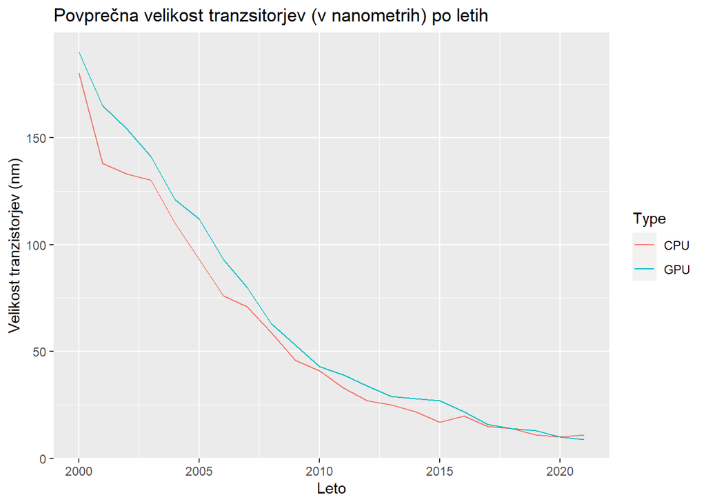

Ker imata med proizvajalci procesorjev najvišji tržni delež podjetji Intel in AMD, me je zanimalo kakšne so razlike v nanometrski tehnologiji med njima. Kot že prej ugotovljeno, ima Intel svoje obrate za proizvodnjo čipov, zato večino svojih potreb pokrije sam. AMD za razliko od Intela svojih obratov nima in uporablja čipe drugih proizvajalcev.

Povprečna velikost tranzsitorjev (v nanometrih) po letih

| Release.Year | mean_size |
| --- | --- |
| 2000 | 186 |
| 2002 | 146 |
| 2004 | 115 |
| 2006 | 84 |
| 2008 | 62 |
| 2010 | 42 |
| 2012 | 31 |
| 2014 | 26 |
| 2016 | 22 |
| 2018 | 14 |
| 2020 | 10 |

### Rast števila tranzistorjev

Predstavil bom še rast povprečnega števila tranzistorjev po letih.

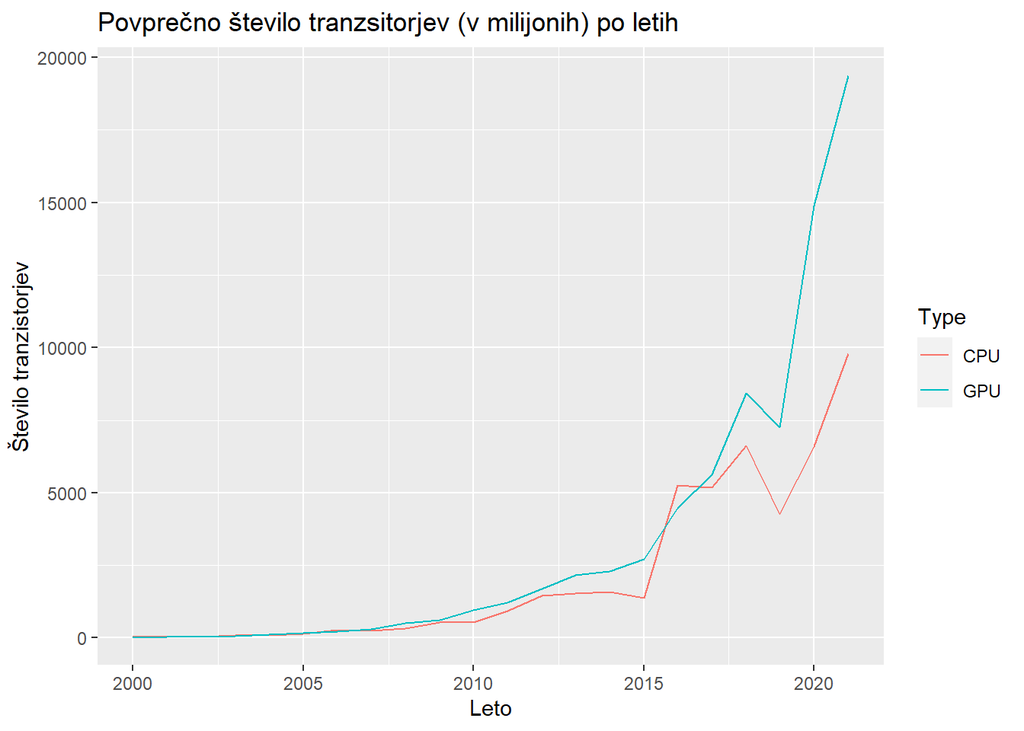

Vse do leta 2016 je povprečno število tranzsitorjev grafičnih kartic precej dobro sledilo procesorjem, kasneje pa je začelo močno rasti in je prehitelo število tranzistorjev v procesorjih. Po podatkih iz leta 2021 je povprečno števillo tranzistorjev na čipih grafičnih kartic približno 2x večje od njihovega števila na procesorjih.

Povprečno število tranzsitorjev (v milijonih) po letih

| Release.Year | mean_transistor_count | increase |
| --- | --- | --- |
| 2000 | 30 | NA |
| 2002 | 51 | 1.70 |
| 2004 | 114 | 2.24 |
| 2006 | 242 | 2.12 |
| 2008 | 447 | 1.85 |
| 2010 | 746 | 1.67 |
| 2012 | 1595 | 2.14 |
| 2014 | 2111 | 1.32 |
| 2016 | 4586 | 2.17 |
| 2018 | 7790 | 1.70 |
| 2020 | 12661 | 1.63 |

Tabela prikazuje rast števila tranzistorjev za procesorje in grafične kartice skupaj. Ker Moorov zakon pravi, da se število tranzsitorjev podvoji približno vsaki dve leti, sem kot takšen izbral tudi interval prikaza vrednosti v tabeli. Stolpec *increase* predstavlja količnik med povprečnim številom tranzistorjev za neko obdobje in prejšnje obdobje dveh let. Pove nam torej za koliko se je število tranzistorjev povečalo v primerjavi s prejšnjim obdobjem. Tako količnik z vrednostjo 2 pomeni, da se je število tranzistorjev v primerjavi s prejšjim obdobjem dveh let podvojilo. Kot je razvidno iz vrednosti se količniki gibljejo okrog vrednosti 2, na podlagi česar bi lahko zaključil, da Moorov zakon še vedno drži.

### Rast frekvenc procesorjev in grafičnih kartic

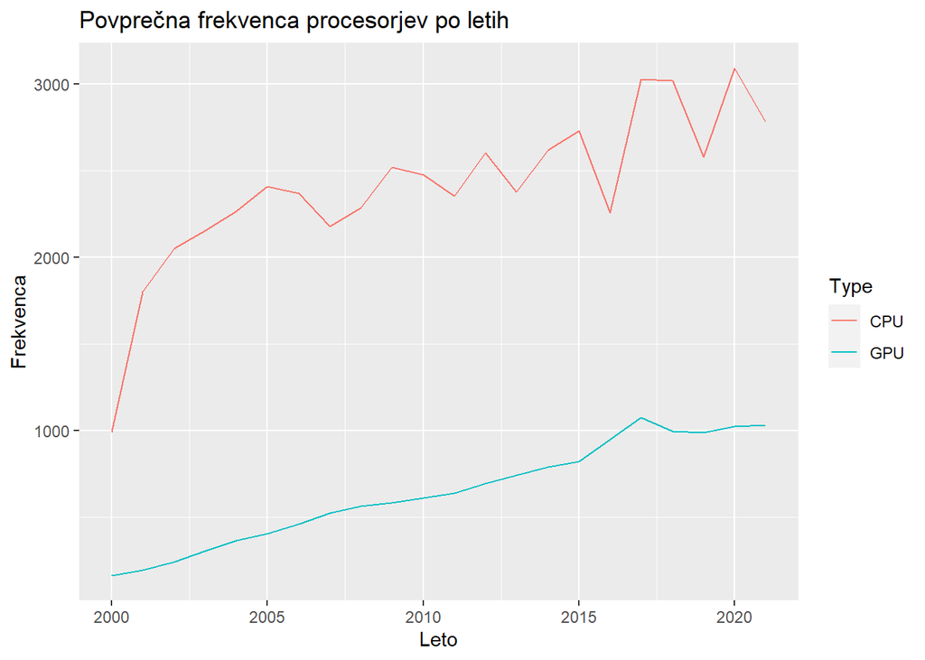

Pri primerjavi frekvenc med procesorji in grafičnimi karticami je mogoče opaziti, da so te veliko višje pri procesorjih. Rast povprečne frekvence procesorjev je bila najbolj očitna med letoma 2000 in 2005, po letu 2005 pa se je precej upočasnila in se v zadnjih nekaj letih giblje med 2.5GHz in 3GHz. Pri čipih grafičnih kartic je drugače - kakor je razvidno z grafa je rast frekvenc skozi leta precej konstantna.

### Korelacije med lastnostmi čipov

Pred izdelavo grafov sem iz podatkov odstranil osamelce iz odvisne spremenljivke.

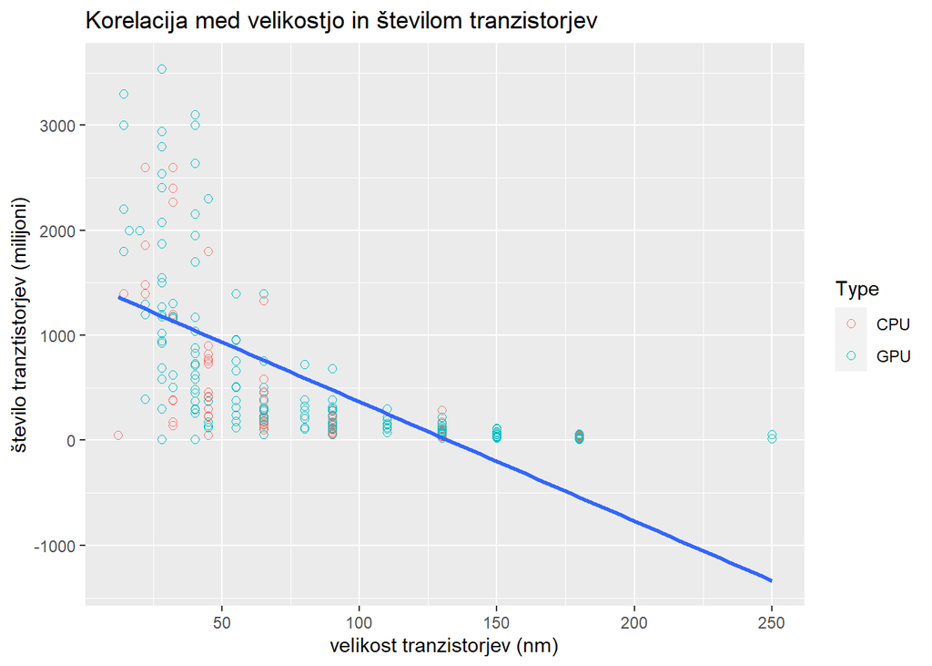

Pričakovano se število tranzistorjev na integriranem vezju povečuje z manjšanjem njihove velikosti. Spremenljivki sta torej negativno korelirani.

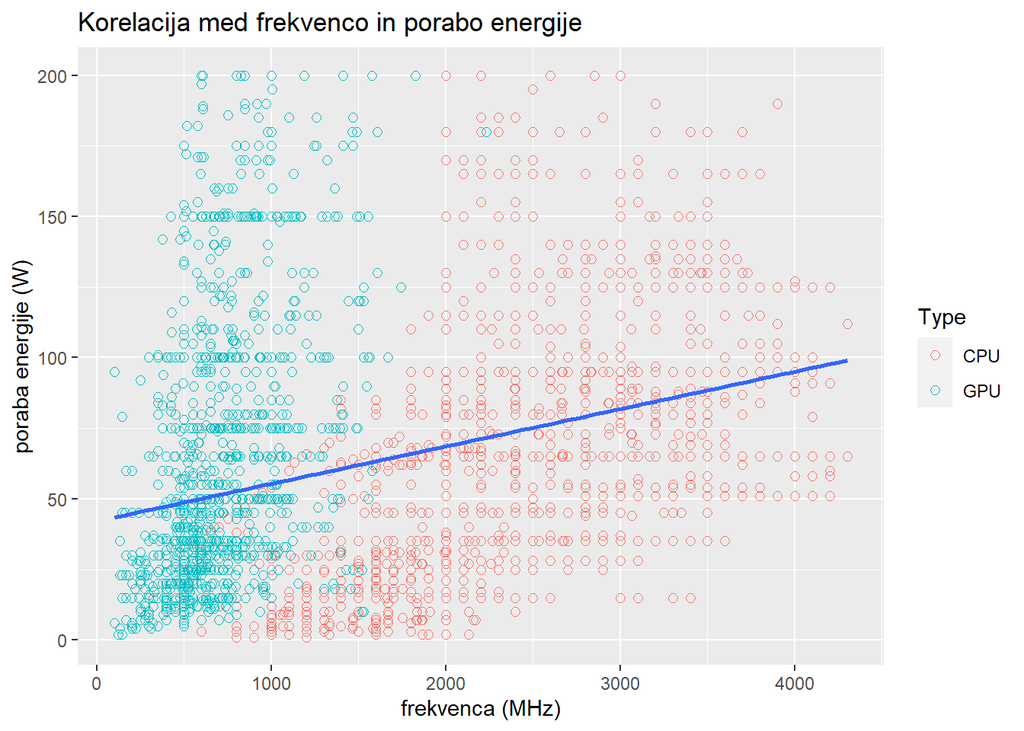

Poraba energije in frekvenca procesorja sta pozitivno korelirani spremenljivki. Iz grafa je lepo razvidno tudi, da grafične kartice dosegajo precej nižje frekvence od procesorjev. Zanimivo je, da sta razpona frekvenc za procesorje in grafične kartice zelo lepo ločena in tvorita skoraj ločeni skupini na grafu.

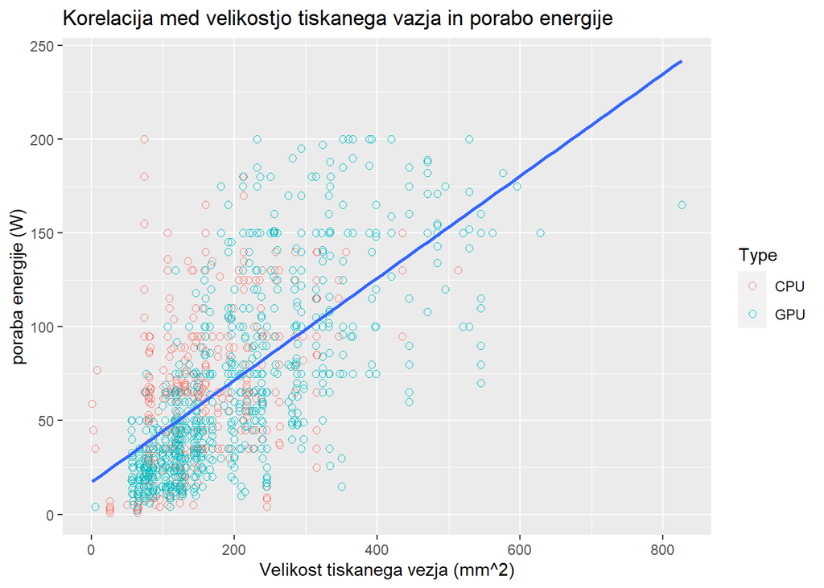

Z večanjem velikosti tiskanih vezij se povečuje tudi poraba energije. Tudi ti dve spremenljivki sta pozitivno korelirani.

### Primerjava procesorjev Intel in AMD

Na koncu analize bi rad primerjal še naketere lastnosti in našel morebitne razlike med procesorji Intel in AMD. Predvsem me zanima ali v zadnjih letih obstajajo razlike v frekvenci in številu tranzistorjev med proizvajalcema. Za primerjavo sem izbral obdobje od leta 2010 do 2021.

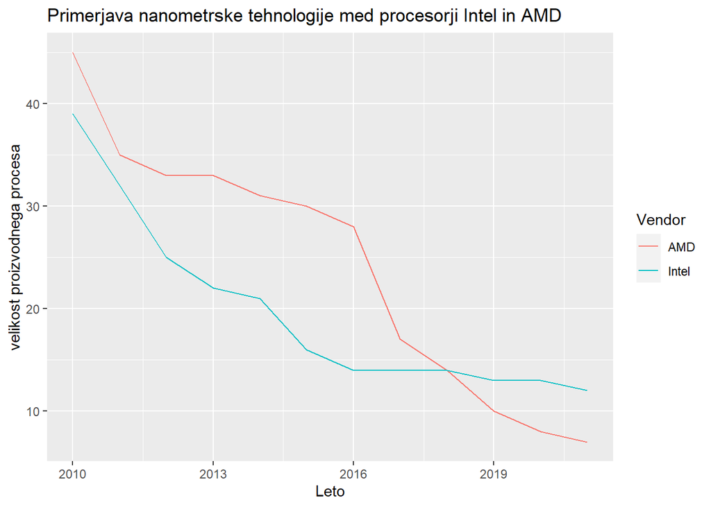

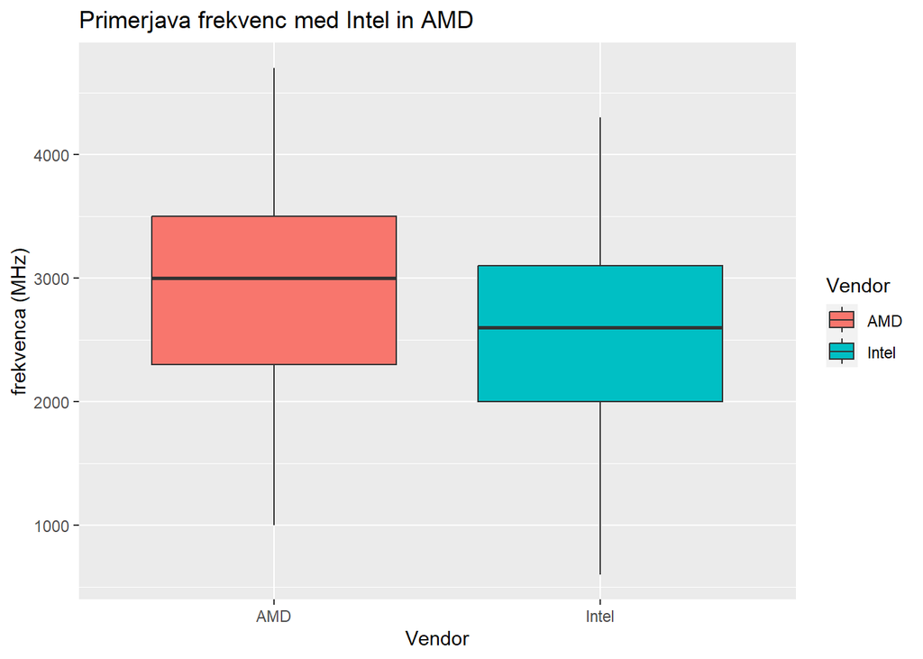

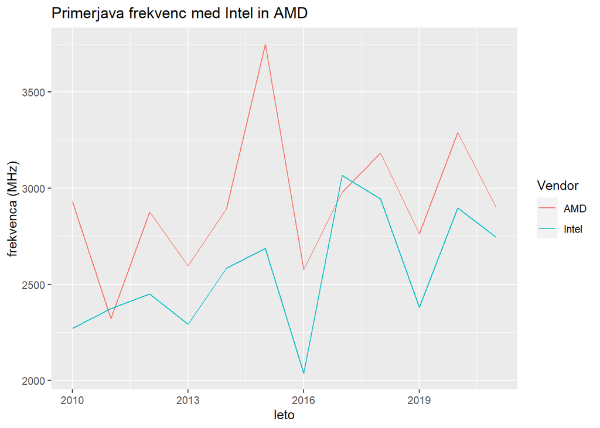

Primerjava Intel Xeon in AMD Threadripper procesorjev

| Vendor | mean_frequency | mean_transistors | mean_tdp |
| --- | --- | --- | --- |
| AMD Threadripper | 3395.00 | 9200.000 | 219.5000 |
| Intel Xeon | 2433.96 | 3161.847 | 156.5495 |

Želel sem primerjati še najzmogljivejše procesorje in prikazati razlike med Intelom in AMD. AMD-jevi najzmogljivejši procesorji Threadripper, izdelani po letu 2014, imajo v povprečju višje frekvence, več tranzistorjev, ampak tudi višjo povprečno porabo energije od Intelove družine Xeon.

### Primerjava grafičnih kartic NVIDIA in AMD

Podobno primerjavo bom izpeljal še za grafične kartice.

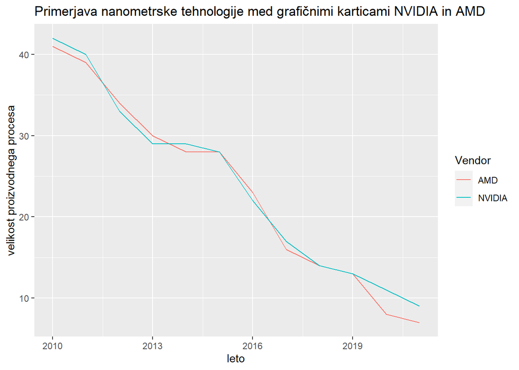

Pri primerjavi velikosti tranzistorjev med največjima proizvajalcema grafičnih kartic so razlike precej manjše kot pri procesorjih. Oba proizvajalca sta v svojih grafičnih karticah uporabljala skoraj enake velikosti čipov. To je verjetno posledica, da obema podjetjema čipe dobavjla TSMC, zaradi česar ni prišlo do večjih razlik.

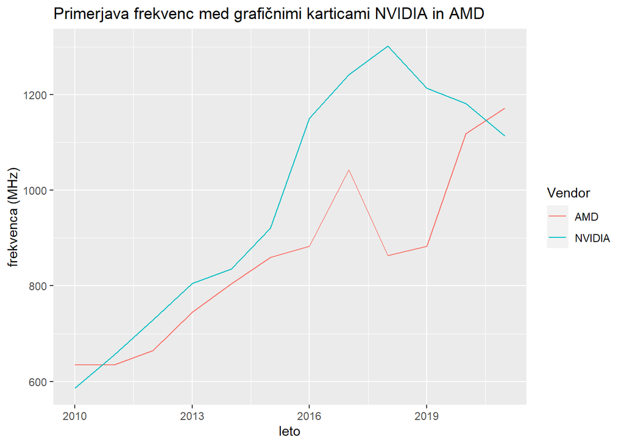

## Zaključek

V tej analizi sem predstavil trend povečevanja zmogljivosti čipov, vgrajenih v procesorje in grafične kartice. Prikazal sem trend manjšanja velikosti tranzistorjev in s tem večanje njihovega tevila na tiskanih vezjih. Ugotovil sem, da Moorov zakon v zadnjih letih še vedno velja, predvsem to drži za čipe grafičnih kartic, katerih število tranzistorjev se je v zadnjih 5 letih močno povečalo in so s tem prehitele procesorje. Prikazal sem rast frekvenc skozi leta in ugotovil, da imajo grafične kartice v povprečju nižje frekvence, je pa njihova rast bolj konstantna kakor pri procesorjih.

Pri ugotavljanju korelacij sem ugotovil, da se z manjšanjem velikosti proizvodnega procesa viša število tranzistorjev. Z višanjem frekvence procesorjev se povečuje njihova poraba energije, poraba energije pa se povečuje tudi z večanjem velikosti tiskanega vezja.

Britannica. 2023. “Moore’s Law Britannica.” https://www.britannica.com/technology/Moores-law.

BRYANT, MICHAEL. 2022. “CPU and GPU Performances Dataset.” https://www.kaggle.com/datasets/michaelbryantds/cpu-and-gpu-product-data.

Wikipedia. 2023a. “AMD Wikipedia.” https://en.wikipedia.org/wiki/AMD.

———. 2023b. “AMD Zen3 Wikipedia.” https://en.wikipedia.org/wiki/Zen_3.

———. 2023c. “Intel Rocket Lake Wikipedia.” https://en.wikipedia.org/wiki/Rocket_Lake.